# The Reading Gap? How schools in Ontario Compare

Reading is a fundamental skill that shapes how students learn, communicate, and navigate everyday life. It is the foundation for learning across different subjects, from solving mathematical word problems, to understanding science and history. Students who developed a solid foundation in reading by Grade 3 are more likely to succeed academically, while those who struggle at an early stage may face challenges in their later education if these difficulties are not addressed.

Since 2017, students in Ontario have experienced significant disruptions to their education, including school closures due to pandemic, two years of cancelled assessments, and ongoing debates over how reading should be taught. Nevertheless, the overall reading performance appears remarkably stable. In 2017-18, about 74% of Grade 3 students across Ontario met the provincial reading standard. By 2024-25, the figure remained approximately the same.

However, overall provincial figures may overlook significant variations in reading performance across schools. Using school-level reading results across Ontario, this article explores the relationship between students’ socioeconomic backgrounds and student reading achievement. How large is the performance gap between the most affluent and high-poverty schools, and has it narrowed over time? Do high-poverty schools make greater progress by Grade 6? Additionally, does the proportion of students whose first language is not English relate to reading performance?

## Has provincial reading changed since 2017?

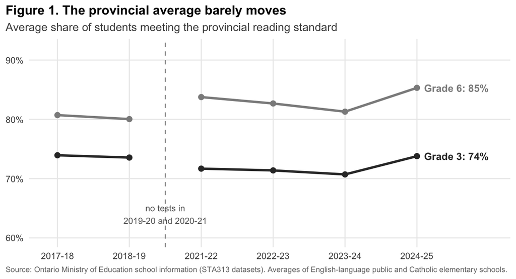

We started with the number most people see: the provincial average. In the average school, about 74% of Grade 3 students met the reading standard in 2017-18, and in 2024-25 it was still about 74% (Figure 1). There was a dip after the pandemic, down to around 71% in 2023-24, but it came back. Grade 6 went up a little, from about 81% to 85%.

We expected a bigger change, especially after COVID. If you only looked at this chart, you would think not much has happened to reading in Ontario. But this average is one number for more than 3,500 schools, so we wondered whether every school really stayed the same or whether some went up while others went down. To find out, we split schools into five groups based on how many children in the area live in low-income households.

## How big is the gap between the richest and poorest schools, and is it closing?

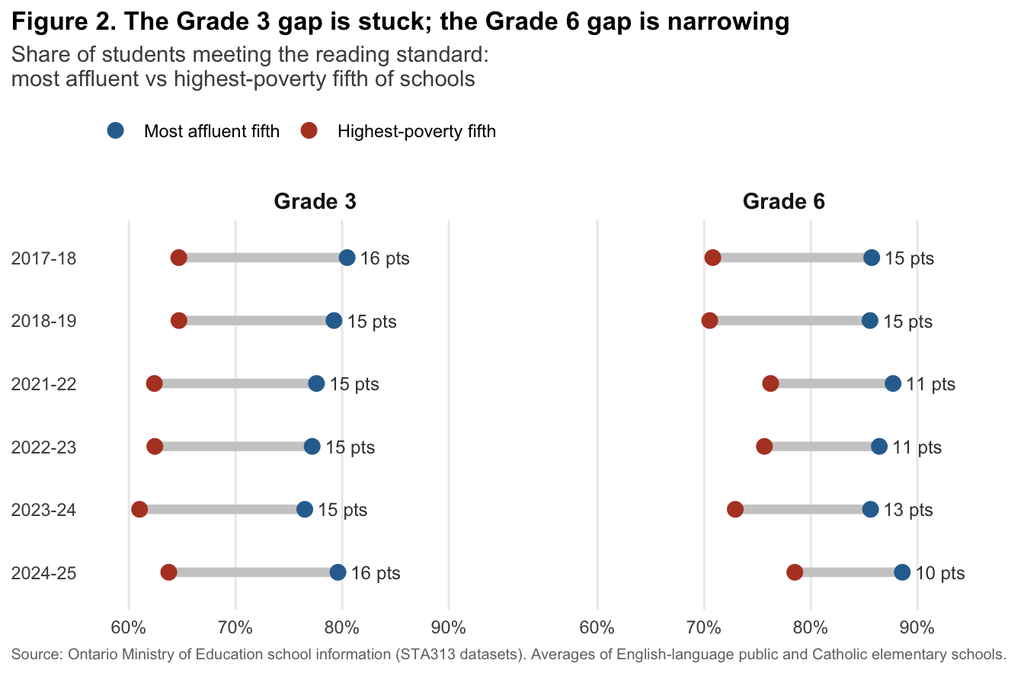

Splitting schools by income showed us what the average was hiding. In Grade 3, students in the most affluent fifth of schools were about 16 percentage points more likely to meet the standard than students in the highest-poverty fifth, and that gap barely moved in seven years (Figure 2). In a class of 30, that’s about five more kids in a high-poverty school who aren’t meeting the provincial standard.

Grade 6 looked different, which we didn’t expect. Before the pandemic the gap was about the same as in Grade 3 (around 15 points), but once testing came back in 2021-22 it was closer to 11, and by 2024-25 it was about 10. So the gap stays the same in Grade 3 but gets smaller by Grade 6. Since the Grade 3 class of 2021-22 is the Grade 6 class of 2024-25, we decided to follow those students.

## Do students in poorer schools catch up from Grade 3 to Grade 6?

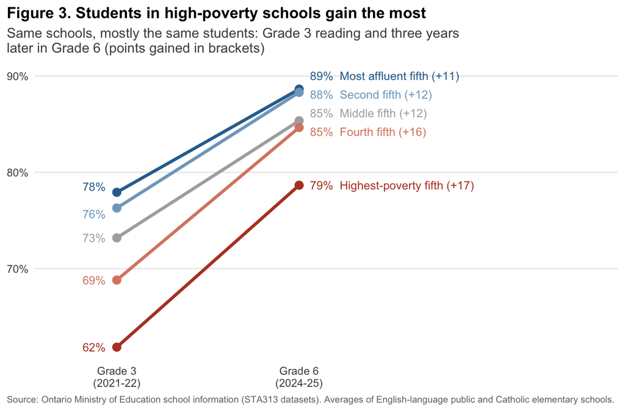

To do this, we compared each school’s Grade 3 result in 2021-22 with its Grade 6 result three years later, when most of the same kids would be in Grade 6. Every group improved, but the high-poverty schools improved the most: about 17 points, compared with about 11 for the most affluent schools (Figure 3). By Grade 6 the gap between them went from about 16 points to about 10. We checked the class before (Grade 3 in 2018-19 to Grade 6 in 2021-22) and saw the same thing, just smaller (about 12 points vs 8).

One thing to keep in mind is that affluent schools were already near 90% in Grade 6, so they didn’t have much room to grow. Even so, high-poverty schools start Grade 3 so far behind that the gap never fully closes. Poorer areas also tend to have more students whose first language isn’t English, so our next question was whether language explains the gap.

## Is the gap really about English learners?

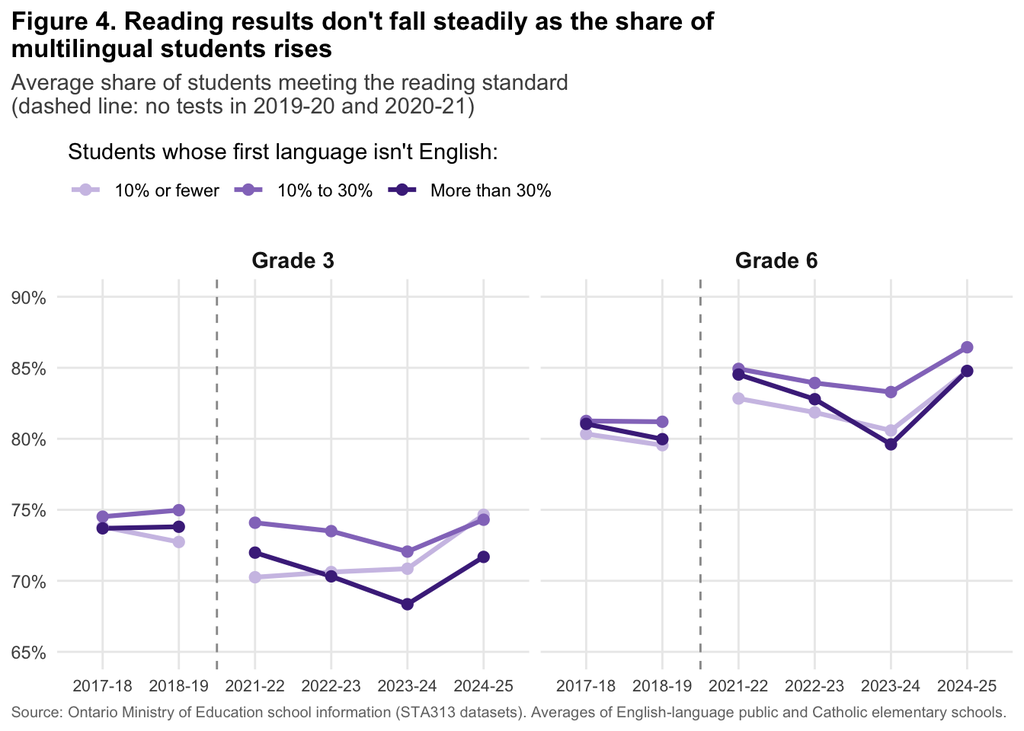

We also examined whether schools with different proportions of students whose first language is not English demonstrate differences in reading performance. Figure 4 compares the average share of students who attained the provincial reading standard across these groups for both Grade 3 and Grade 6. Contrary to our expectation, the findings did not align with our initial assumption. Before EQAO testing was cancelled in 2019-20 and 2020-21, schools where 10% or fewer of students’ first language is not English generally recorded slightly lower reading scores than those where this proportion is 30% or more. Yet, the differences between the two groups were relatively small.

A more noticeable trend emerges among schools in the middle category. Those where students with a first language other than English account for 10% to 30% of total enrollment generally achieved the highest average results in almost every year, across both grades. Following the resumption of testing, schools with the lowest proportion of these students were seen to improve and their averages increased to levels comparable with the middle group in 2024-25. A similar improvement was not observed in Grade 6.

## Limitations

All of our numbers are percentages for whole schools, not individual students, and we averaged schools without weighting them by size. A school of 100 students counts the same as one with 700, so we can’t say anything about individual kids. We used 3,525 regular English-language public and Catholic elementary schools.

We also ran into a few problems with the data. Schools with fewer than 10 test takers have no results, so some small schools are missing; Grade 3 reading is blank in about 1 in 9 school-years. The file has numbers for 2019-20 and 2020-21 even though there were no EQAO tests those years because of COVID. When we checked, 99.9% of the Grade 3 values were exactly the same as 2018-19, so we took those years out. The 2023-24 numbers were stored as decimals (like 0.73) instead of percents, so we multiplied them by 100. The low-income numbers also switch to newer census data in 2022-23 and drop noticeably, so we kept each school in the income group it was in for 2017-18.

For the Grade 3 to Grade 6 comparison, students change schools, so it isn’t exactly the same kids, and affluent schools had little room left to improve. The test also moved online after the pandemic, which could make results before and after a bit different. With student-level data, or results weighted by enrolment, we could check these findings more carefully.

## Conclusion

Ontario’s average reading results have remained relatively stable, yet the overall trend hides a persistent achievement gap between schools in different income areas. About 75% of Grade 3 students in the average school continue to meet the reading standard after seven years. However, schools in the highest-poverty group score approximately 16 percentage points lower than those in the most affluent, with little improvement over time.

In addition, language diversity does not appear to be a major factor to the disparity of reading achievements. Schools with a larger share of students whose first language do not necessarily perform worse in reading. In fact, schools where these students made up 10% to 30% of total enrollment tend to perform the best. This suggests that socioeconomic factors may be more closely related to differences in reading achievements than the language background of students.

One key takeaway is that disparities in reading performance are already significant by Grade 3. While high-poverty schools show greater progress by Grade 6, they still struggle to catch up with the most affluent schools. This raises an important question for policymakers and educators: should interventions begin even sooner to help bridge the gap, if these inequalities emerge so early.